# cd_06_Salifort_Motors_TEAM_SUMMARY-example-output

## Management Evaluation Scores

- Examine the last evaluation scores you chose to gauge the perceived effectiveness of the team member.
- Identify patterns in feedback and recognize areas for improvement.
- Consider conducting feedback sessions to better understand team members' expectations and concerns.

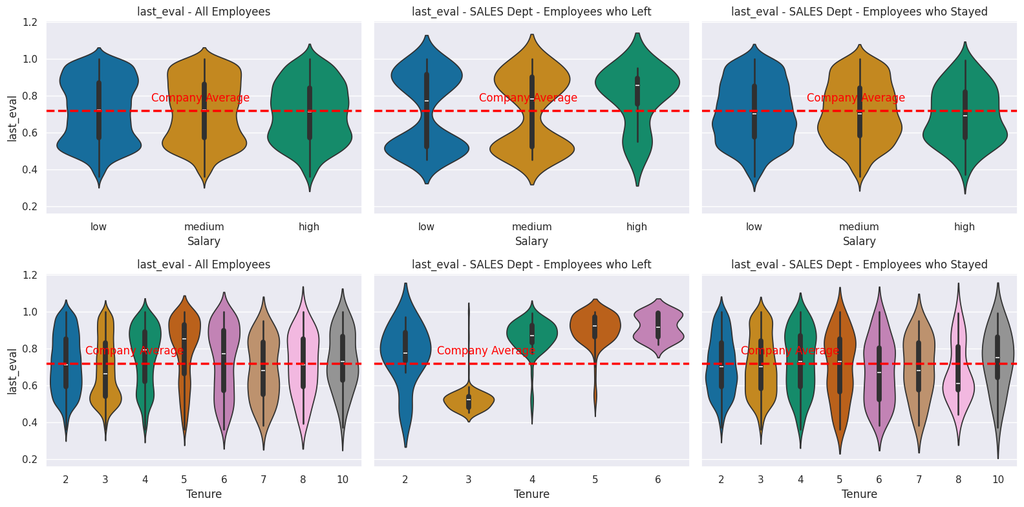

## Work Hours

- Analyze the distribution of work hours among team members.
- Identify any instances of excessive overtime or uneven workloads.
- Balancing work hours is crucial for maintaining a healthy work-life balance and preventing burnout.

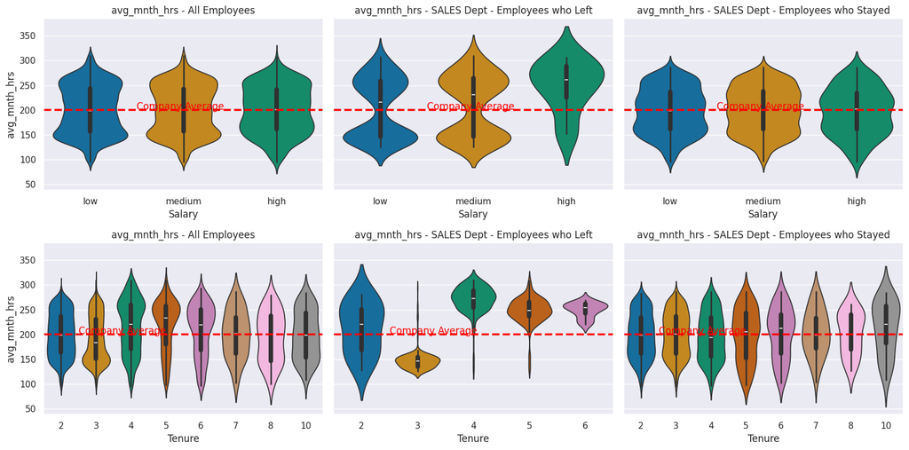

## Project Involvement

- Examine the number of projects each team member has been involved in.
- Assess whether workload distribution is equitable and aligned with individual capacities.
- Consider redistributing projects to ensure a fair and manageable workload for each team member.

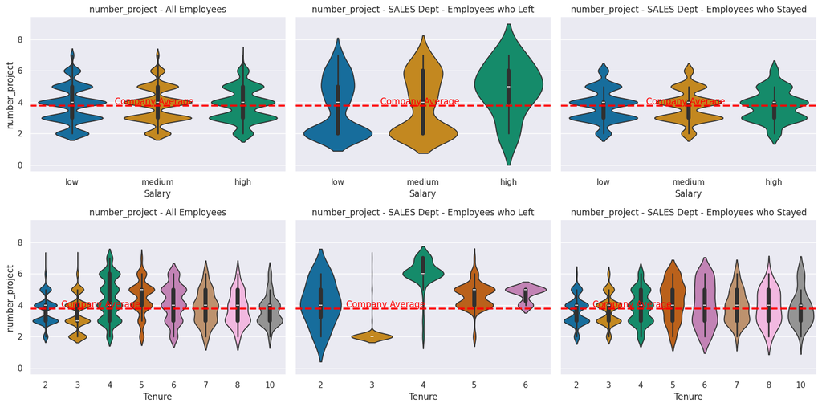

## Salary Levels

- Review the salary levels within the team.
- Address any disparities or concerns related to compensation that may affect employee satisfaction.
- Ensure that salary levels are competitive and reflective of employees' contributions.

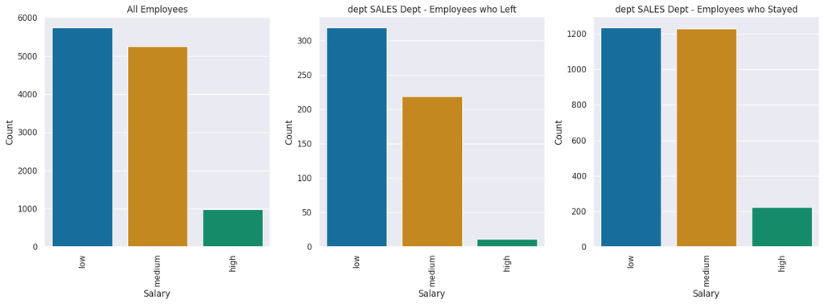

## Employee Retention Prediction

Utilizing a machine learning model, the HR team have developed predictions for employee attrition within your team. The model takes into account various factors to identify potential risks. Please consider the provided predictions as a proactive tool for retention strategies.

Key Recommendations:

- Implement regular check-ins to discuss job satisfaction, career aspirations, and any challenges team members may be facing.
- Consider opportunities for professional development and career growth to enhance employee engagement.
- Ensure workload distribution is fair and aligned with individual skills and capacities.
- Address any concerns raised during management evaluation scores to strengthen leadership effectiveness.

Remember, this summary serves as a starting point for discussions and actions to improve team dynamics. I am available to discuss these findings further and collaborate on tailored strategies for your team.

## Employees at risk of leaving

The following is a summary of the results from asking the ML Model to assess a risk of leaving for current team members.

```
XGBoost Summary for CURRENT SALES Employees

───────────────────────────────────────────────────────

probabilities > high_risk_threshold 90%
Count of employees with leave probability above 90%        : 2
Percentage of employees with leave probability above 90%   : 0.08%

probabilities > medium_risk_threshold 70%
Count of employees with leave probability above 70%        : 6
Percentage of employees with leave probability above 70%   : 0.24%

probabilities > predict_risk_threshold 50%
Count of employees with leave probability above 50%        : 17
Percentage of employees with leave probability above 50%   : 0.69%
```

scroll to top